# Assignment 1

2024-03-28

**Jeremy Djohar Riyadi Group 6**

### Dataset Description

Dataset : World Happiness Report 2023 Source: The World Happiness Report (a partnership of Gallup, the Oxford Wellbeing Research Centre, the UN Sustainable Development Solutions Network, and the WHR’s Editorial Board)

Dataset variable description:

- country: country name
- region: geographic region or continent
- happiness_score: a measure of overall happiness
- gdp_per_capita: measure of gross domestic product per capita
- social_support: a measure of the quality of social support offered by the country and a person’s social life
- healthy_life_expectancy: a measure of a person’s healthy life expectancy
- freedom_to_make_life_choices: someone’s freedom to make decisions - generosity: a measure of someone’s generosity
- perceptions_of_corruption: a person’s perception of corruption in a country

### Calls the libraries and functions used

```r
source("explorationFunction.R") # for BasicSummary function

library(corrplot) # to create a correlation plot to look for correlation between variables
library(ggplot2) # to create a plot: bar plot, scatter plot
library(dplyr) # for data manipulation and transformation: filter(), group_by(), others
```

### Opens a CSV file and converts it to a dataframe

```r
x = read.csv("WHR_2023.csv")
df = data.frame(x)
```

Displays a dataframe so it is easy to see what data is contained in it. It is known that the dataframe has 137 rows and 9 columns.

## View variable characters

```r
str(df)
```

```
## 'data.frame':    137 obs. of  9 variables:
##  $ country                     : chr  "Finland" "Denmark" "Iceland" "Israel" ...
##  $ region                      : chr  "Western Europe" "Western Europe" "Western Europe" "Middle East and North Africa" ...
##  $ happiness_score             : num  7.8 7.59 7.53 7.47 7.4 ...
##  $ gdp_per_capita              : num  1.89 1.95 1.93 1.83 1.94 ...
##  $ social_support              : num  1.58 1.55 1.62 1.52 1.49 ...
##  $ healthy_life_expectancy     : num  0.535 0.537 0.559 0.577 0.545 0.562 0.544 0.582 0.549 0.513 ...
##  $ freedom_to_make_life_choices: num  0.772 0.734 0.738 0.569 0.672 0.754 0.752 0.678 0.71 0.672 ...
##  $ generosity                  : num  0.126 0.208 0.25 0.124 0.251 0.225 0.212 0.151 0.149 0.23 ...
##  $ perceptions_of_corruption   : num  0.535 0.525 0.187 0.158 0.394 0.52 0.463 0.475 0.418 0.471 ...
```

The dataframe has 137 observations with 9 variables, 2 categorical and 7 numerical. The two categorical variables, namely country and region, have character data types. Meanwhile, the numerical variables consist of happiness_score, gdp_per_capita, social_support, healthy_life_expectancy, freedom_to_make_life_choices, generosity, and perceptions_of_corruption. The first 5 data for each variable in the dataframe are also displayed.

```r
summary(df)
```

```
##    country             region          happiness_score gdp_per_capita
##  Length:137         Length:137         Min.   :1.859   Min.   :0.000
##  Class :character   Class :character   1st Qu.:4.724   1st Qu.:1.099
##  Mode  :character   Mode  :character   Median :5.684   Median :1.449
##                                        Mean   :5.540   Mean   :1.407
##                                        3rd Qu.:6.334   3rd Qu.:1.798
##                                        Max.   :7.804   Max.   :2.200
##
##  social_support  healthy_life_expectancy freedom_to_make_life_choices
##  Min.   :0.000   Min.   :0.0000          Min.   :0.000
##  1st Qu.:0.962   1st Qu.:0.2485          1st Qu.:0.455
##  Median :1.227   Median :0.3895          Median :0.557
##  Mean   :1.156   Mean   :0.3662          Mean   :0.540
##  3rd Qu.:1.401   3rd Qu.:0.4875          3rd Qu.:0.656
##  Max.   :1.620   Max.   :0.7020          Max.   :0.772
##                  NA's   :1
##    generosity     perceptions_of_corruption
##  Min.   :0.0000   Min.   :0.0000
##  1st Qu.:0.0970   1st Qu.:0.0600
##  Median :0.1370   Median :0.1110
##  Mean   :0.1485   Mean   :0.1459
##  3rd Qu.:0.1990   3rd Qu.:0.1870
##  Max.   :0.4220   Max.   :0.5610
##
```

Displays summary data in the dataframe, in the form of the mean, 5 number summary, and the number of missing values(NA). It can be seen that for the variable healthy_life_expectancy there is 1 null value.

## Check and delete null values

```r
sum(is.na(df))
```

```
## [1] 1
```

```r
which(!complete.cases(df)) # palestine -> healthy_life_expectancy (row 99)
```

```
## [1] 99
```

```r
df <- df[-99, ]
rownames(df) <- seq_len(nrow(df))
# so that the index is directly connected
```

### Check duplicated values

```r
duplicated(df) #no duplication
```

```
##   [1] FALSE FALSE FALSE FALSE FALSE FALSE FALSE FALSE FALSE FALSE FALSE FALSE
##  [13] FALSE FALSE FALSE FALSE FALSE FALSE FALSE FALSE FALSE FALSE FALSE FALSE
##  [25] FALSE FALSE FALSE FALSE FALSE FALSE FALSE FALSE FALSE FALSE FALSE FALSE
##  [37] FALSE FALSE FALSE FALSE FALSE FALSE FALSE FALSE FALSE FALSE FALSE FALSE
##  [49] FALSE FALSE FALSE FALSE FALSE FALSE FALSE FALSE FALSE FALSE FALSE FALSE
##  [61] FALSE FALSE FALSE FALSE FALSE FALSE FALSE FALSE FALSE FALSE FALSE FALSE
##  [73] FALSE FALSE FALSE FALSE FALSE FALSE FALSE FALSE FALSE FALSE FALSE FALSE
##  [85] FALSE FALSE FALSE FALSE FALSE FALSE FALSE FALSE FALSE FALSE FALSE FALSE
##  [97] FALSE FALSE FALSE FALSE FALSE FALSE FALSE FALSE FALSE FALSE FALSE FALSE
## [109] FALSE FALSE FALSE FALSE FALSE FALSE FALSE FALSE FALSE FALSE FALSE FALSE
## [121] FALSE FALSE FALSE FALSE FALSE FALSE FALSE FALSE FALSE FALSE FALSE FALSE
## [133] FALSE FALSE FALSE FALSE
```

There are no duplicate values.

### Looking for outliers in the happiness_score variable

```r
FindOutliers(df$happiness_score)
```

```
## $summary
##        method   n nMiss nOut   lowLim    upLim minNom maxNom
## 1  ThreeSigma 136     0    1 2.115920 8.972963  2.392  7.804
## 2      Hampel 136     0    1 2.288709 9.098291  2.392  7.804
## 3 BoxplotRule 136     0    9 3.882500 8.802500  3.982  7.804
##
## $threeSigma
##   index values type
## 1   136  1.859    L
##
## $Hampel
##   index values type
## 1   136  1.859    L
##
## $boxplotRule
##   index values type
## 1   128  3.694    L
## 2   129  3.545    L
## 3   130  3.495    L
## 4   131  3.435    L
## 5   132  3.207    L
## 6   133  3.204    L
## 7   134  3.138    L
## 8   135  2.392    L
## 9   136  1.859    L
```

According to the Three Sigma method there is 1 outlier. According to the Hampel method, there is 1 outlier. According to the Boxplot Rule there are 9 outliers.

### Removing outliers (using Z score)

```r
sd(df$happiness_score) # standard deviation before outliers are removed
```

```
## [1] 1.142841
```

```r
threshold <- sd(df$happiness_score) * 3

# Remove rows with happiness_score values greater than the threshold
dfCleaned <- df %>%
  filter(abs(happiness_score - mean(happiness_score)) < threshold)

sd(dfCleaned$happiness_score) # standar deviasi setelah outlier dihapus
```

```
## [1] 1.101689
```

Standard deviation before the outlier is removed = 1.142841 Standard deviation after the outlier is removed = 1.101689 Because the difference is only 0.04, the outlier does not have much effect on the data so it does not need to be removed

### Looking for outliers in the gdp_per_capita variable

```r
FindOutliers(df$gdp_per_capita)
```

```
## $summary
##        method   n nMiss nOut     lowLim    upLim minNom maxNom
## 1  ThreeSigma 136     0    1  0.1070118 2.710826  0.531    2.2
## 2      Hampel 136     0    0 -0.1119017 3.014902  0.000    2.2
## 3 BoxplotRule 136     0   10  0.7476250 2.848375  0.758    2.2
##
## $threeSigma
##   index values type
## 1    88      0    L
##
## $Hampel
## [1] index  values type
## <0 rows> (or 0-length row.names)
##
## $boxplotRule
##    index values type
## 1     88  0.000    L
## 2     97  0.570    L
## 3    108  0.561    L
## 4    113  0.622    L
## 5    124  0.628    L
## 6    126  0.632    L
## 7    130  0.637    L
## 8    132  0.531    L
## 9    134  0.670    L
## 10   136  0.645    L
```

According to the Three Sigma method there is 1 outlier. According to the Hampel method there are 0 outliers. According to the Boxplot Rule there are 10 outliers.

### Looking for outliers in the social_support variable

```r
FindOutliers(df$social_support)
```

```
## $summary
##        method   n nMiss nOut    lowLim    upLim minNom maxNom
## 1  ThreeSigma 136     0    1 0.1732997 2.136877  0.242   1.62
## 2      Hampel 136     0    2 0.2892381 2.161762  0.327   1.62
## 3 BoxplotRule 136     0   18 0.7390000 2.063500  0.756   1.62
##
## $threeSigma
##   index values type
## 1   136      0    L
##
## $Hampel
##   index values type
## 1   115  0.242    L
## 2   136  0.000    L
##
## $boxplotRule
##    index values type
## 1     86  0.665    L
## 2     93  0.584    L
## 3     99  0.535    L
## 4    101  0.727    L
## 5    107  0.657    L
## 6    108  0.628    L
## 7    115  0.242    L
## 8    117  0.513    L
## 9    118  0.614    L
## 10   119  0.637    L
## 11   121  0.642    L
## 12   124  0.644    L
## 13   125  0.674    L
## 14   129  0.327    L
## 15   130  0.479    L
## 16   134  0.540    L
## 17   135  0.476    L
## 18   136  0.000    L
```

According to the Three Sigma method there is 1 outlier. According to the Hampel method, there are 2 outliers. According to the Boxplot Rule there are 18 outliers.

### Looking for outliers in the healthy_life_expectancy variable

```r
FindOutliers(df$healthy_life_expectancy)
```

```
## $summary
##        method   n nMiss nOut     lowLim     upLim minNom maxNom
## 1  ThreeSigma 136     0    0 -0.1038968 0.8362498  0.000  0.702
## 2      Hampel 136     0    0 -0.1308926 0.9098926  0.000  0.702
## 3 BoxplotRule 136     0   15  0.1290000 0.8460000  0.137  0.702
##
## $threeSigma
## [1] index  values type
## <0 rows> (or 0-length row.names)
##
## $Hampel
## [1] index  values type
## <0 rows> (or 0-length row.names)
##
## $boxplotRule
##    index values type
## 1     91  0.072    L
## 2     93  0.120    L
## 3     95  0.092    L
## 4     96  0.118    L
## 5     97  0.000    L
## 6    103  0.107    L
## 7    113  0.043    L
## 8    115  0.124    L
## 9    119  0.106    L
## 10   127  0.095    L
## 11   131  0.087    L
## 12   132  0.105    L
## 13   133  0.069    L
## 14   134  0.092    L
## 15   136  0.087    L
```

According to the Three Sigma method there are 0 outliers. According to the Hampel method there are 0 outliers. According to the Boxplot Rule there are 15 outliers.

### Looking for outliers in the freedom_to_make_life_choices variable

```r
FindOutliers(df$freedom_to_make_life_choices)
```

```
## $summary
##        method   n nMiss nOut     lowLim     upLim minNom maxNom
## 1  ThreeSigma 136     0    1 0.09189811 0.9899254  0.117  0.772
## 2      Hampel 136     0    1 0.11272000 1.0022800  0.117  0.772
## 3 BoxplotRule 136     0   13 0.35975000 0.9537500  0.363  0.772
##
## $threeSigma
##   index values type
## 1   136      0    L
##
## $Hampel
##   index values type
## 1   136      0    L
##
## $boxplotRule
##    index values type
## 1     58  0.248    L
## 2     81  0.252    L
## 3     94  0.346    L
## 4     98  0.351    L
## 5    100  0.281    L
## 6    102  0.320    L
## 7    105  0.125    L
## 8    109  0.259    L
## 9    118  0.286    L
## 10   126  0.187    L
## 11   129  0.117    L
## 12   135  0.123    L
## 13   136  0.000    L
```

According to the Three Sigma method there is 1 outlier. According to the Hampel method, there is 1 outlier. According to the Boxplot Rule there are 13 outliers.

### Look for outliers in the loyalty variable

```r
FindOutliers(df$generosity)
```

```
## $summary
##        method   n nMiss nOut      lowLim     upLim minNom maxNom
## 1  ThreeSigma 136     0    2 -0.07889173 0.3770682  0.000  0.332
## 2      Hampel 136     0    2 -0.08711390 0.3621139  0.000  0.332
## 3 BoxplotRule 136     0   12  0.04812500 0.3503750  0.053  0.332
##
## $threeSigma
##   index values type
## 1    84  0.422    U
## 2   116  0.400    U
##
## $Hampel
##   index values type
## 1    84  0.422    U
## 2   116  0.400    U
##
## $boxplotRule
##    index values type
## 1     24  0.044    L
## 2     47  0.009    L
## 3     56  0.031    L
## 4     58  0.008    L
## 5     90  0.000    L
## 6     94  0.036    L
## 7     99  0.013    L
## 8    109  0.022    L
## 9    120  0.038    L
## 10   131  0.021    L
## 11    84  0.422    U
## 12   116  0.400    U
```

According to the Three Sigma method there are 2 outliers. According to the Hampel method, there are 2 outliers. According to the Boxplot Rule there are 12 outliers.

### Looking for outliers in the perception_of_corruption variable

```r
FindOutliers(df$perceptions_of_corruption)
```

```
## $summary
##        method   n nMiss nOut     lowLim     upLim minNom maxNom
## 1  ThreeSigma 136     0    2 -0.2345482 0.5275041      0  0.525
## 2      Hampel 136     0   12 -0.1437485 0.3677485      0  0.365
## 3 BoxplotRule 136     0   11 -0.0045000 0.3810000      0  0.372
##
## $threeSigma
##   index values type
## 1     1  0.535    U
## 2    25  0.561    U
##
## $Hampel
##    index values type
## 1      1  0.535    U
## 2      2  0.525    U
```

[output cut: 24 more lines]

According to the Three Sigma method there are 2 outliers. According to the Hampel method there are 12 outliers. According to the Boxplot Rule there are 11 outliers.

### View correlation between numerical variables

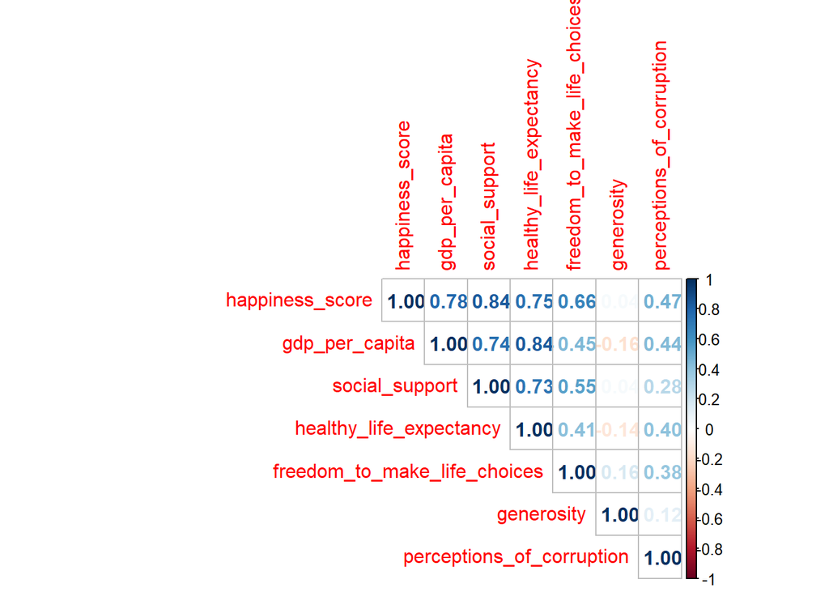

```r
newDf <- subset(df, select = -c(region, country))

c <- cor(newDf)
corrplot(c, type="upper", method="number")
```

### Correlation tests on several variables to prove the correlation plot

```r
cor.test(newDf$happiness_score, newDf$gdp_per_capita, method = c("pearson")) #0.7843422
```

```
##
##  Pearson's product-moment correlation
##
## data:  newDf$happiness_score and newDf$gdp_per_capita
## t = 14.611, df = 134, p-value < 2.2e-16
## alternative hypothesis: true correlation is not equal to 0
## 95 percent confidence interval:
##  0.7090285 0.8411605
## sample estimates:
##       cor
## 0.7838113
```

```r
cor.test(newDf$gdp_per_capita, newDf$social_support, method = c("pearson")) #0.7379928
```

```
##
##  Pearson's product-moment correlation
##
## data:  newDf$gdp_per_capita and newDf$social_support
## t = 12.801, df = 134, p-value < 2.2e-16
## alternative hypothesis: true correlation is not equal to 0
## 95 percent confidence interval:
##  0.6551854 0.8090358
## sample estimates:
##       cor
## 0.7417151
```

```r
cor.test(newDf$gdp_per_capita, newDf$healthy_life_expectancy, method = c("pearson")) #0.8375183
```

```
##
##  Pearson's product-moment correlation
##
## data:  newDf$gdp_per_capita and newDf$healthy_life_expectancy
## t = 17.743, df = 134, p-value < 2.2e-16
## alternative hypothesis: true correlation is not equal to 0
## 95 percent confidence interval:
##  0.7790120 0.8815663
## sample estimates:
##       cor
## 0.8375183
```

```r
cor.test(newDf$happiness_score, newDf$healthy_life_expectancy, method = c("pearson")) #0.7466993
```

```
##
##  Pearson's product-moment correlation
##
## data:  newDf$happiness_score and newDf$healthy_life_expectancy
## t = 12.995, df = 134, p-value < 2.2e-16
## alternative hypothesis: true correlation is not equal to 0
## 95 percent confidence interval:
##  0.6615149 0.8128605
## sample estimates:
##       cor
## 0.7466993
```

### Average happiness score by region

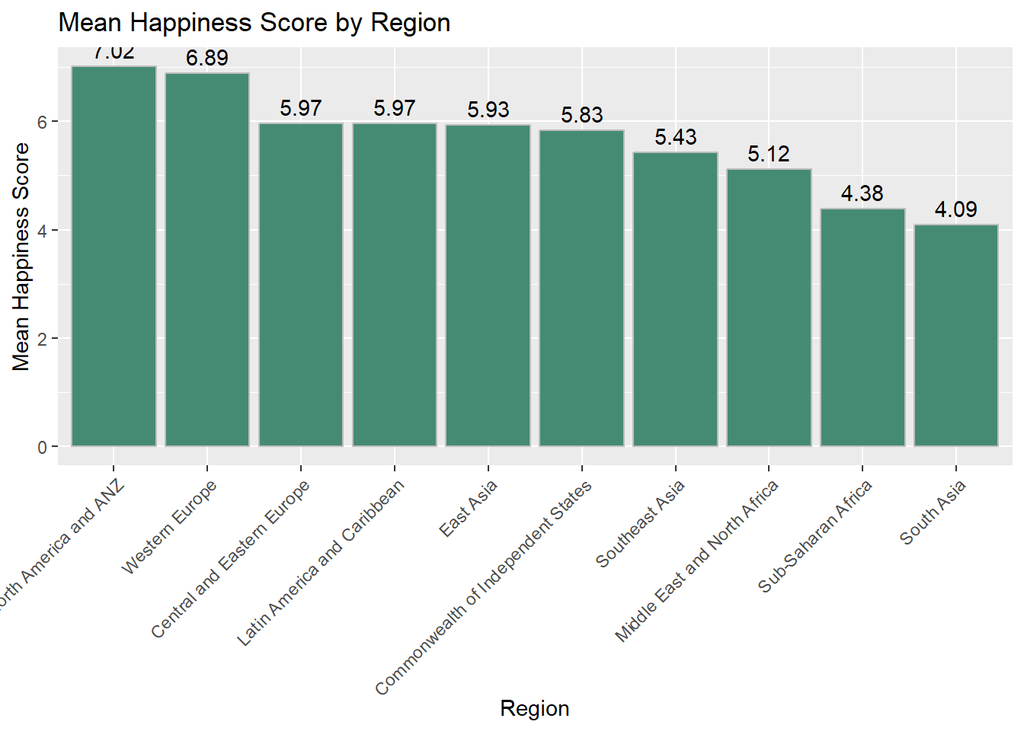

```r
happinessByRegion <- df %>%
  group_by(region) %>%
  summarize(mean_happiness = mean(happiness_score, na.rm = TRUE))

ggplot(happinessByRegion,
       aes(x = reorder(region, -mean_happiness), y = mean_happiness)) +
  geom_bar(stat = "identity", fill = "#458B74", color = "gray") +
  geom_text(aes(label = round(mean_happiness, 2)), vjust = -0.5) +
  labs(x = "Region", y = "Mean Happiness Score", title = "Mean Happiness Score by Region") +
  theme(axis.text.x = element_text(angle = 45, hjust = 1))
```

The bar plot shows a comparison between the average happiness_score per region. It was found that North America and ANZ (Australia and New Zealand) had the highest happiness_score of 7.02.

### Highest Happiness score by country (>7.0)

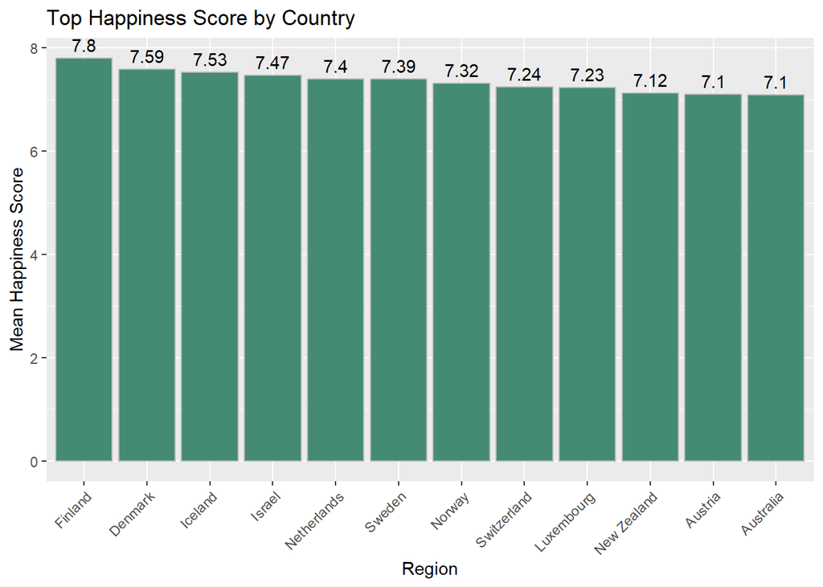

```r
filtered_data <- df %>%
  filter(happiness_score >= 7.0)

ggplot(filtered_data,
       aes(x = reorder(country, -happiness_score), y = happiness_score)) +
  geom_bar(stat = "identity", fill = "#458B74", color = "gray") +
  geom_text(aes(label = round(happiness_score, 2)), vjust = -0.5) +
  labs(x = "Region", y = "Mean Happiness Score", title = "Top Happiness Score by Country") +
  theme(axis.text.x = element_text(angle = 45, hjust = 1))
```

The bar plot shows countries with a happiness_score above 7.0, consisting of 12 countries, namely Finland, Denmark, Iceland, Israel, Netherlands, Sweden, Norway, Switzerland, Luxembourg, New Zealand, Austria and Australia.

## Create a scatter plot to show the relationship between variables

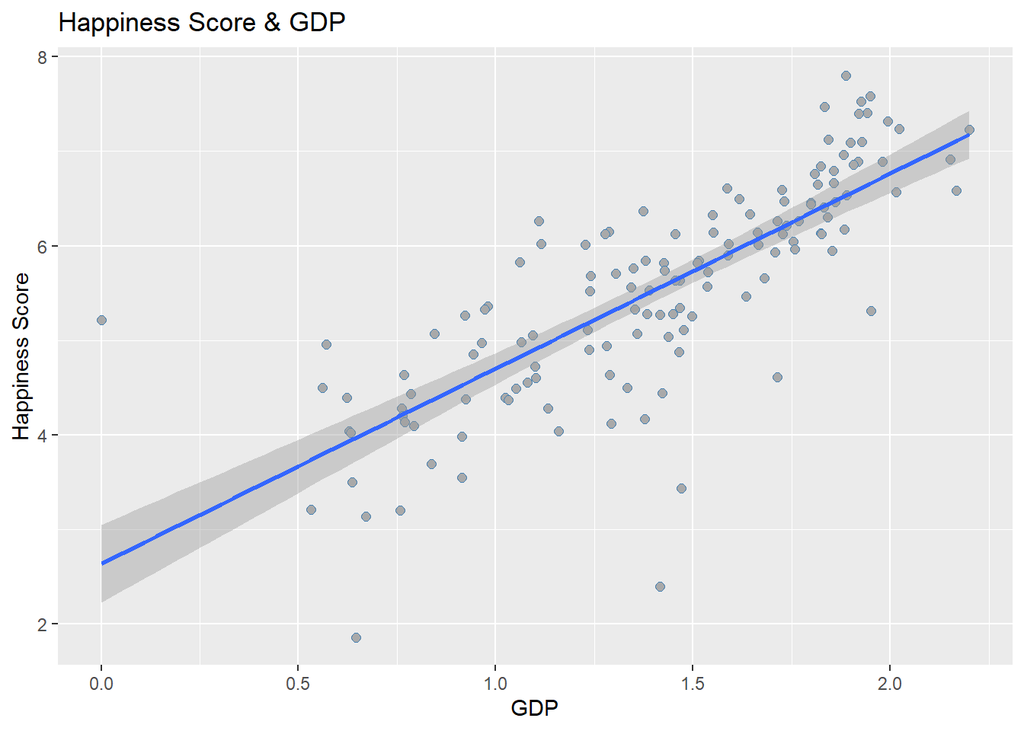

```r
ggplot(data=df, mapping=aes(x=gdp_per_capita,y=happiness_score)) +
  geom_point(pch=21,color="steelblue",fill="darkgray",size=2) +
  labs(x="GDP",y="Happiness Score", title = "Happiness Score & GDP") +
  geom_smooth(method="lm")
```

happiness_score and gdp_per_capita have a linear relationship. The higher the happiness_score, the higher the gdp_per_capita.

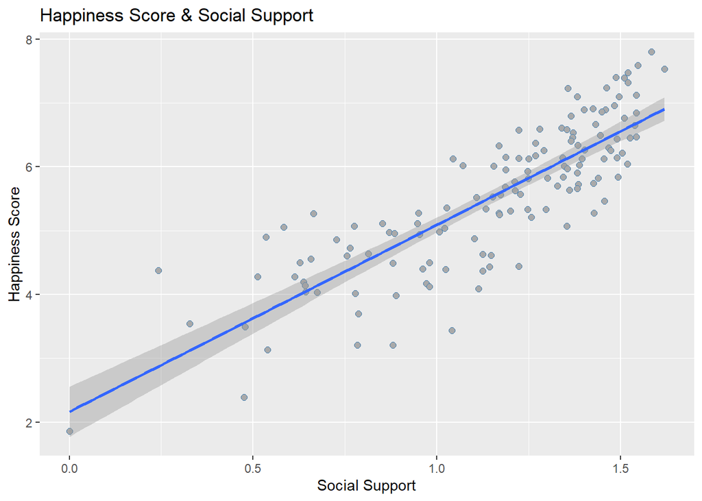

```r
ggplot(data=df, mapping=aes(x=social_support,y=happiness_score)) +
  geom_point(pch=21,color="steelblue",fill="darkgray",size=2) +
  labs(x="Social Support",y="Happiness Score", title = "Happiness Score & Social Support") +
  geom_smooth(method="lm")
```

happiness_score and social_support have a linear relationship. The higher the happiness_score, the higher the social_support.

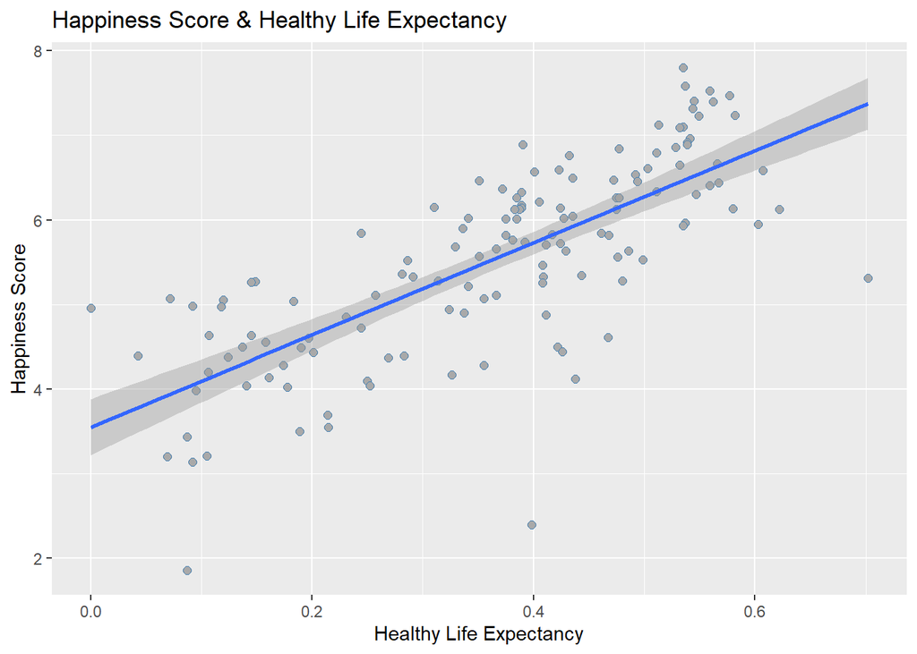

```r
ggplot(data=df, mapping=aes(x=healthy_life_expectancy,y=happiness_score)) +
  geom_point(pch=21,color="steelblue",fill="darkgray",size=2) +
  labs(x="Healthy Life Expectancy",y="Happiness Score", title = "Happiness Score & Healthy Life Expectancy") +
  geom_smooth(method="lm")
```

happiness_score and healthy_life_expectancy have a linear relationship. The higher the happiness_score, the higher the healthy_life_expectancy.

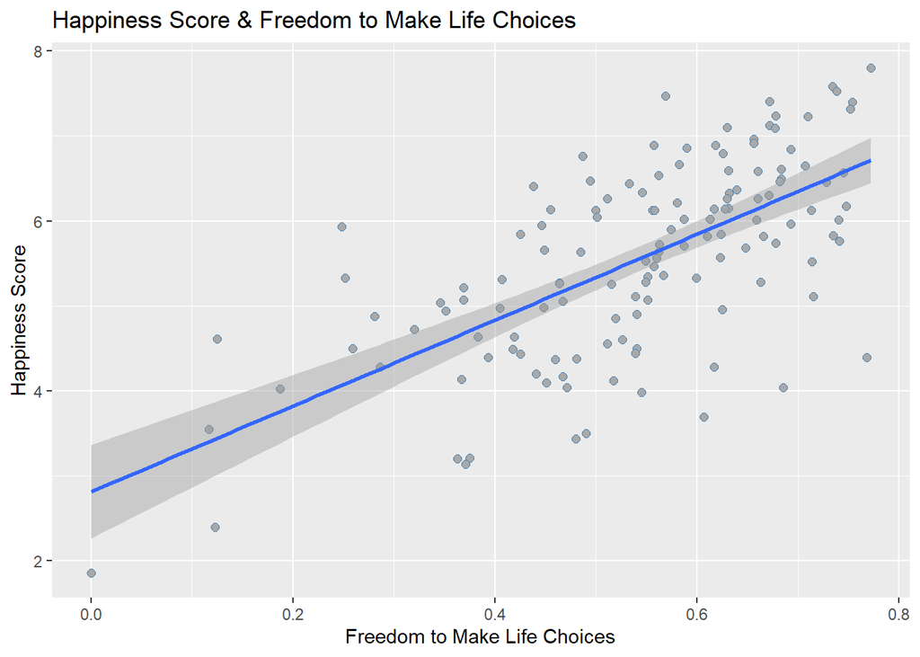

```r
ggplot(data=df, mapping=aes(x=freedom_to_make_life_choices,y=happiness_score)) +
  geom_point(pch=21,color="steelblue",fill="darkgray",size=2) +
  labs(x="Freedom to Make Life Choices",y="Happiness Score", title = "Happiness Score & Freedom to Make Life Choices") +
  geom_smooth(method="lm")
```

happiness_score and freedom_to_make_life_choices have a linear relationship. The higher the happiness_score, the higher the freedom_to_make_life_choices.

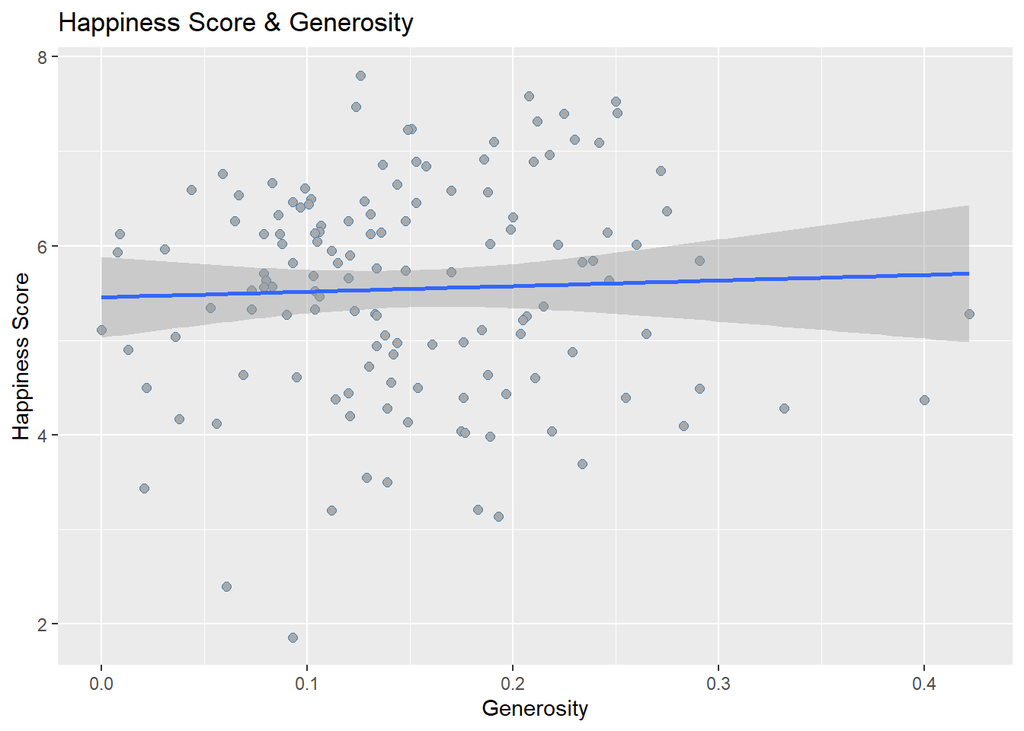

```r
ggplot(data=df, mapping=aes(x=generosity,y=happiness_score)) +
  geom_point(pch=21,color="steelblue",fill="darkgray",size=2) +
  labs(x="Generosity",y="Happiness Score", title = "Happiness Score & Generosity") +
  geom_smooth(method="lm")
```

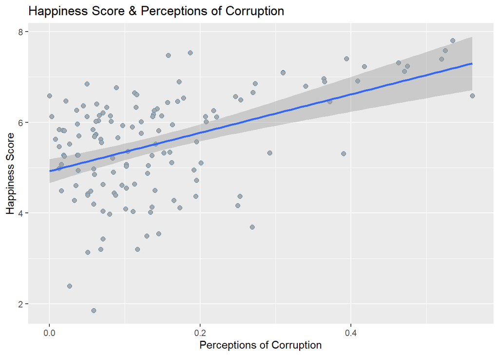

```r
ggplot(data=df, mapping=aes(x=perceptions_of_corruption,y=happiness_score)) +
  geom_point(pch=21,color="steelblue",fill="darkgray",size=2) +
  labs(x="Perceptions of Corruption",y="Happiness Score", title = "Happiness Score & Perceptions of Corruption") +
  geom_smooth(method="lm")
```

happiness_score and perceptions_of_corruption have a linear relationship. The higher the happiness_score, the higher the perception_of_corruption.

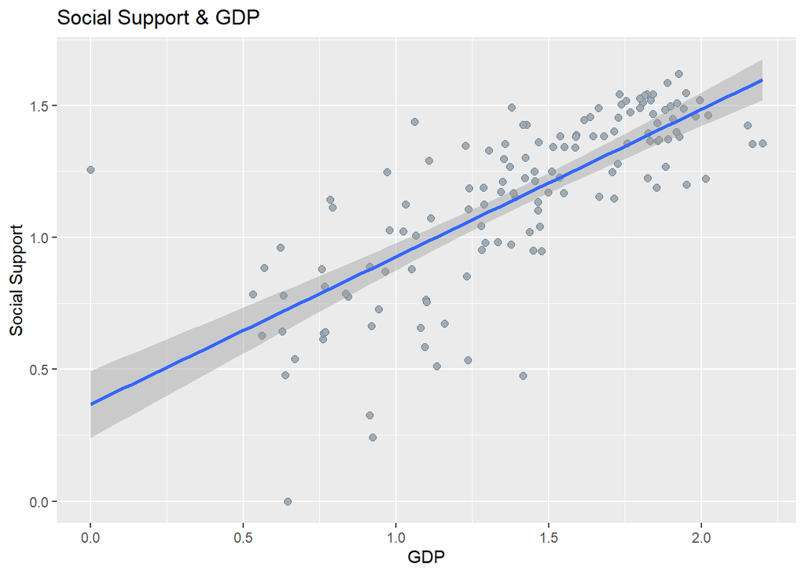

```r
ggplot(data=df, mapping=aes(x=gdp_per_capita,y=social_support)) +
  geom_point(pch=21,color="steelblue",fill="darkgray",size=2) +
  labs(x="GDP",y="Social Support", title = "Social Support & GDP") +
  geom_smooth(method="lm")
```

gdp_per_capita and social_support have a linear relationship. The higher gdp_per_capita, the higher social_support.

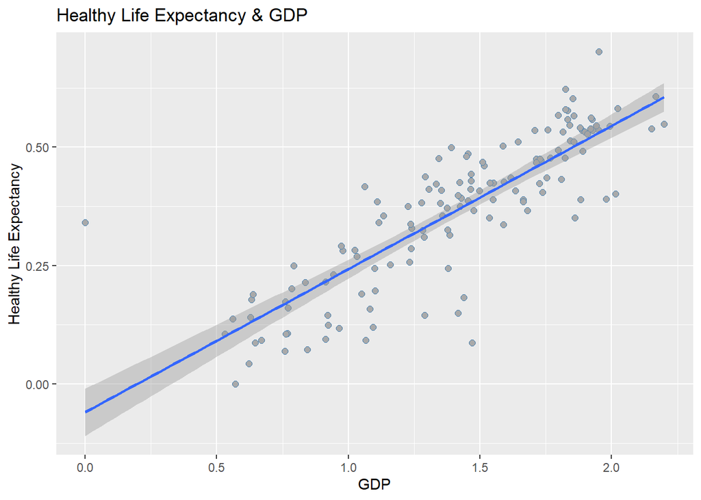

```r
ggplot(data=df, mapping=aes(x=gdp_per_capita,y=healthy_life_expectancy)) +
  geom_point(pch=21,color="steelblue",fill="darkgray",size=2) +
  labs(x="GDP",y="Healthy Life Expectancy", title = "Healthy Life Expectancy & GDP") +
  geom_smooth(method="lm")
```

gdp_per_capita and healthy_life_expectancy have a linear relationship. The higher gdp_per_capita, the higher healthy_life_expectancy.

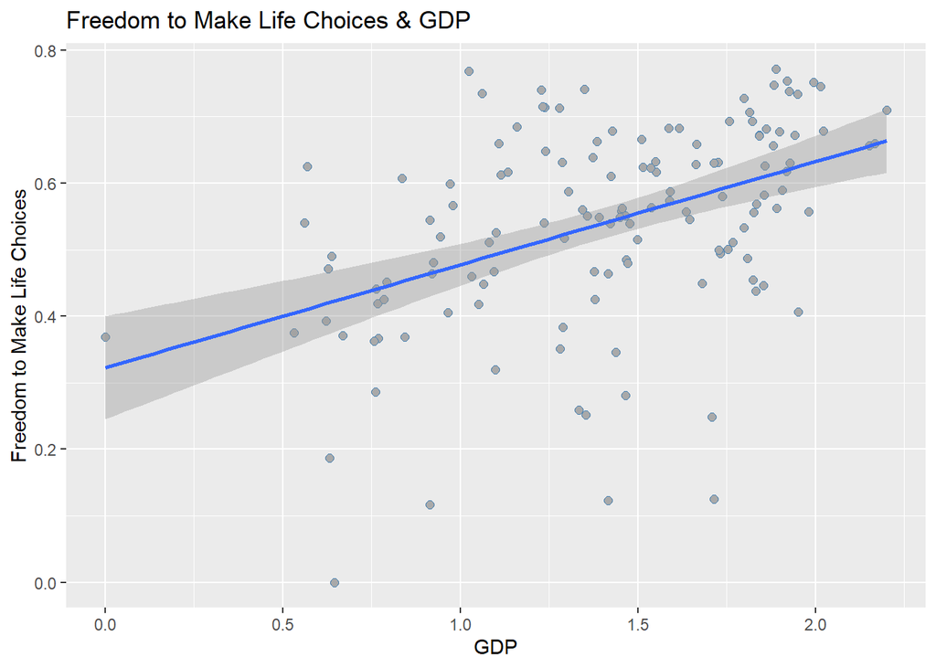

```r
ggplot(data=df, mapping=aes(x=gdp_per_capita,y=freedom_to_make_life_choices)) +
  geom_point(pch=21,color="steelblue",fill="darkgray",size=2) +
  labs(x="GDP",y="Freedom to Make Life Choices", title = "Freedom to Make Life Choices & GDP") +
  geom_smooth(method="lm")
```

gdp_per_capita and freedom_to_make_life_choices have a linear relationship. The higher gdp_per_capita, the higher freedom_to_make_life_choices.

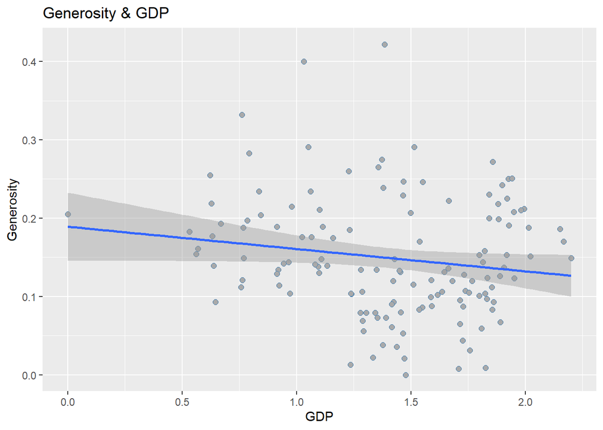

```r
ggplot(data=df, mapping=aes(x=gdp_per_capita,y=generosity)) +
  geom_point(pch=21,color="steelblue",fill="darkgray",size=2) +
  labs(x="GDP",y="Generosity", title = "Generosity & GDP") +
  geom_smooth(method="lm")
```

gdp_per_capita and generosity have a linear relationship. The more gdp_per_capita goes up, the more generosity goes down.

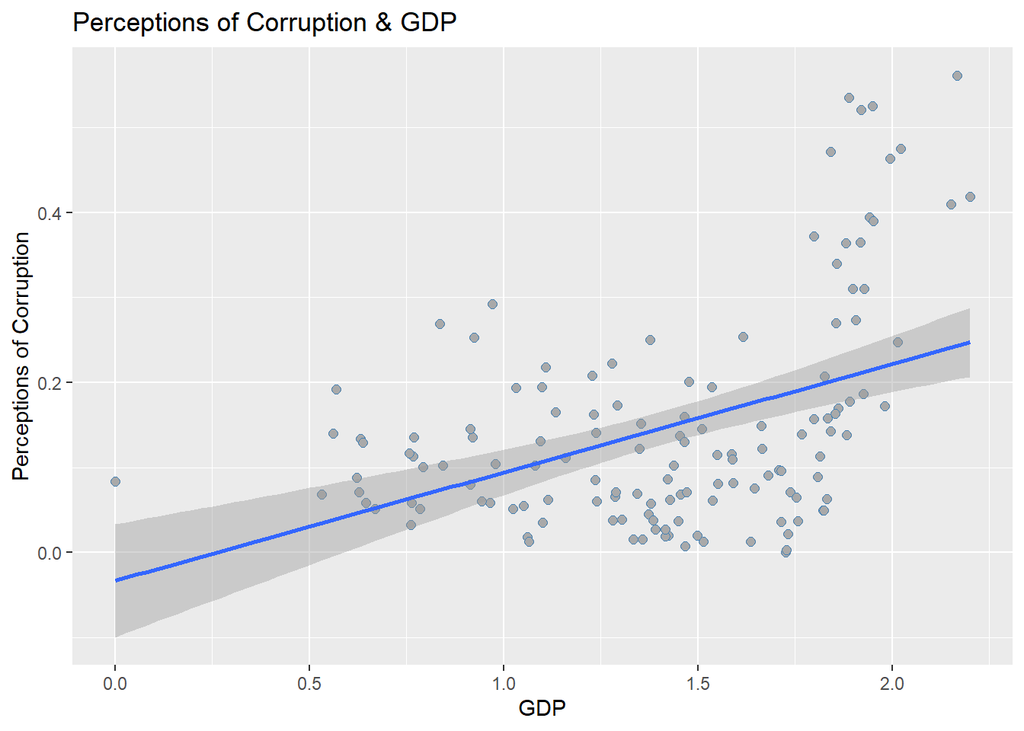

```r
ggplot(data=df, mapping=aes(x=gdp_per_capita,y=perceptions_of_corruption)) +
  geom_point(pch=21,color="steelblue",fill="darkgray",size=2) +
  labs(x="GDP",y="Perceptions of Corruption", title = "Perceptions of Corruption & GDP") +
  geom_smooth(method="lm")
```

gdp_per_capita and perceptions_of_corruption have a linear relationship. The higher gdp_per_capita, the higher perceptions_of_corruption.

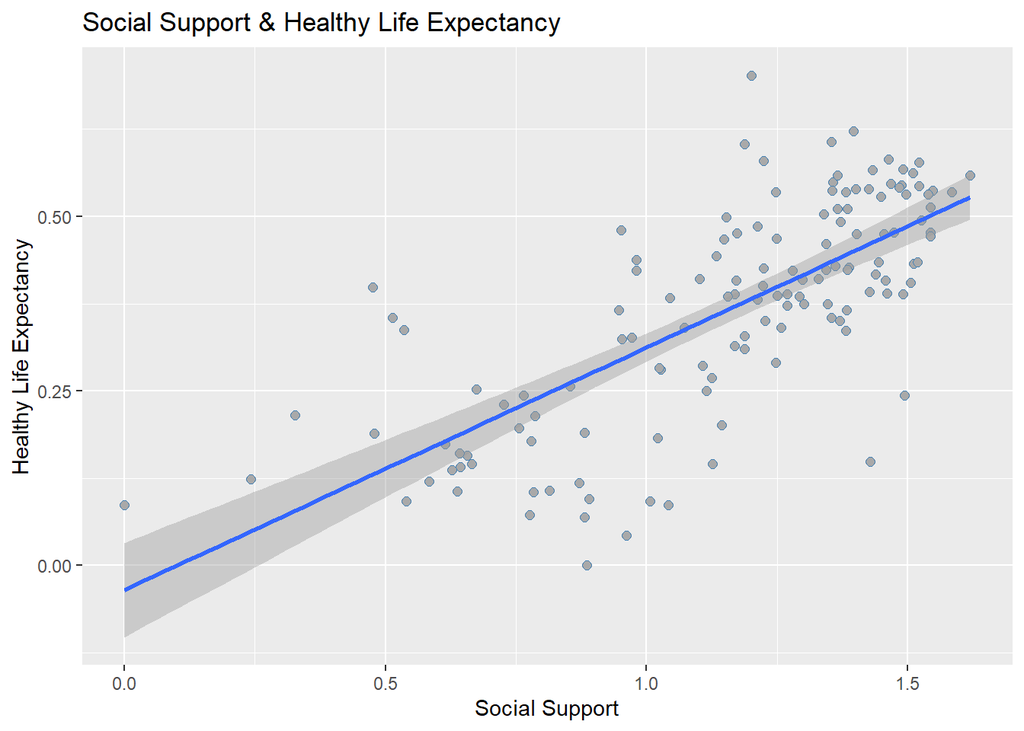

```r
ggplot(data=df, mapping=aes(x=social_support,y=healthy_life_expectancy)) +
  geom_point(pch=21,color="steelblue",fill="darkgray",size=2) +
  labs(x="Social Support",y="Healthy Life Expectancy", title = "Social Support & Healthy Life Expectancy") +   geom_smooth(method="lm")
```

social_support and healthy_life_expectancy have a linear relationship. The higher the social_support, the higher the healthy_life_expectancy.

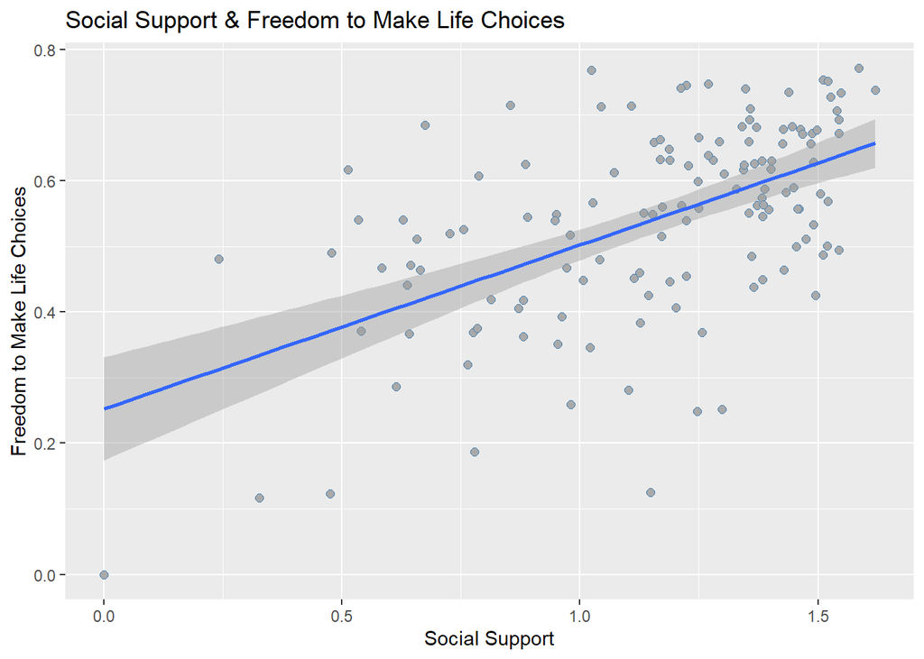

```r
ggplot(data=df, mapping=aes(x=social_support,y=freedom_to_make_life_choices)) +
  geom_point(pch=21,color="steelblue",fill="darkgray",size=2) +
  labs(x="Social Support",y="Freedom to Make Life Choices", title = "Social Support & Freedom to Make Life Choices") +   geom_smooth(method="lm")
```

social_support and freedom_to_make_life_choices have a linear relationship. The higher the social_support, the higher the freedom_to_make_life_choices.

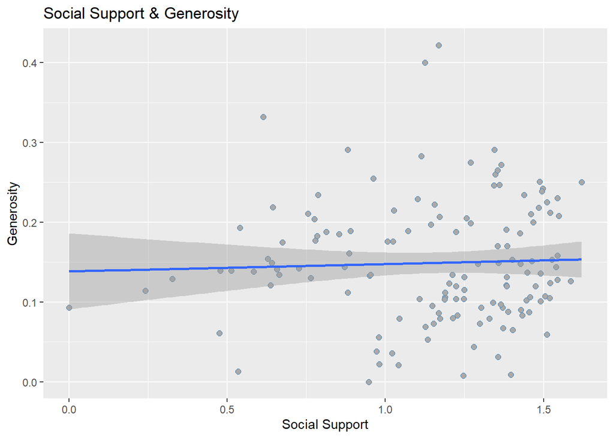

```r
ggplot(data=df, mapping=aes(x=social_support,y=generosity)) +
  geom_point(pch=21,color="steelblue",fill="darkgray",size=2) +
  labs(x="Social Support",y="Generosity", title = "Social Support & Generosity") +   geom_smooth(method="lm")
```

social_support and generosity have a linear relationship. As social_support increases, loyalty remains constant.

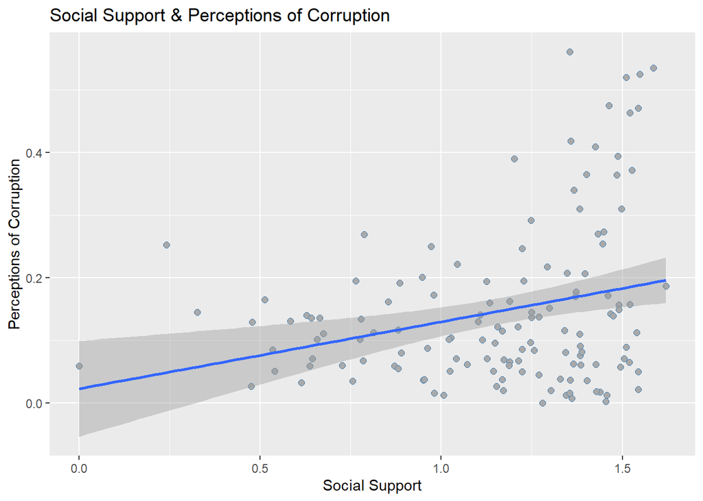

```r
ggplot(data=df, mapping=aes(x=social_support,y=perceptions_of_corruption)) +
  geom_point(pch=21,color="steelblue",fill="darkgray",size=2) +
  labs(x="Social Support",y="Perceptions of Corruption", title = "Social Support & Perceptions of Corruption") +   geom_smooth(method="lm")
```

social_support and perceptions_of_corruption have a linear relationship. The higher the social_support, the higher the perception_of_corruption.

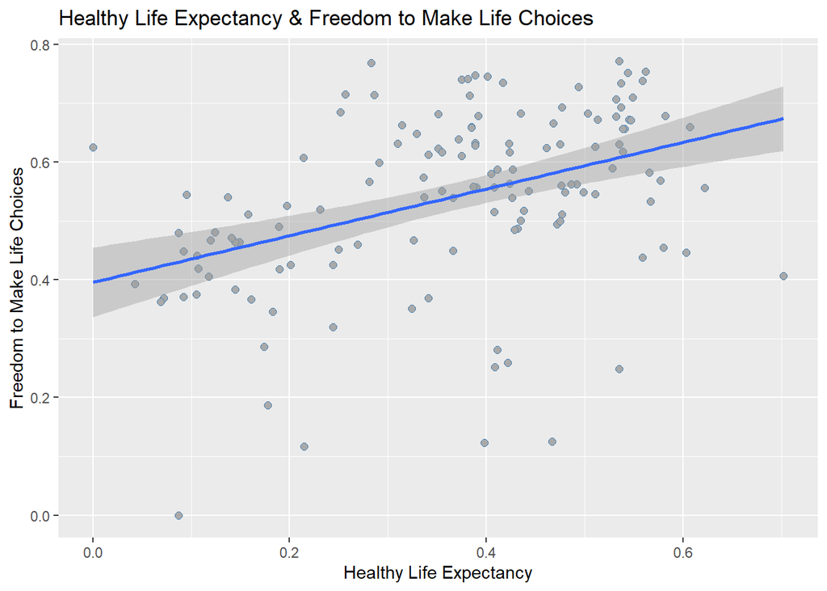

```r
ggplot(data=df, mapping=aes(x=healthy_life_expectancy,y=freedom_to_make_life_choices)) +
  geom_point(pch=21,color="steelblue",fill="darkgray",size=2) +
  labs(x="Healthy Life Expectancy",y="Freedom to Make Life Choices", title = "Healthy Life Expectancy & Freedom to Make Life Choices") +   geom_smooth(method="lm")
```

healthy_life_expectancy and freedom_to_make_life_choices have a linear relationship. The higher the healthy_life_expectancy, the higher the freedom_to_make_life_choices.

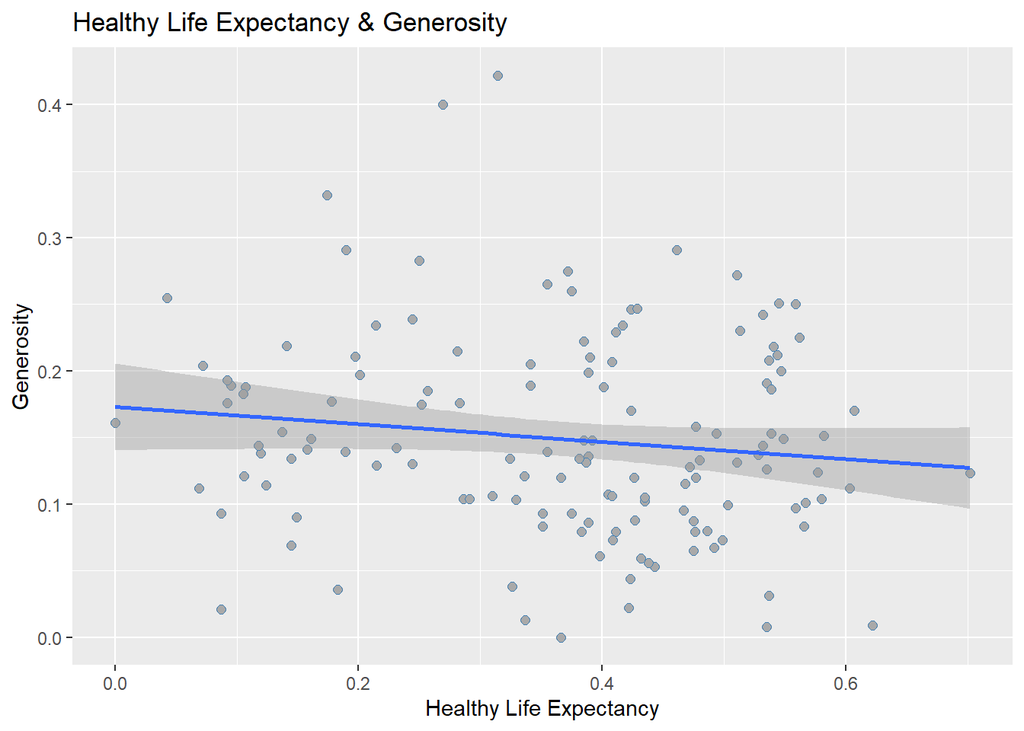

```r
ggplot(data=df, mapping=aes(x=healthy_life_expectancy,y=generosity)) +
  geom_point(pch=21,color="steelblue",fill="darkgray",size=2) +
  labs(x="Healthy Life Expectancy",y="Generosity", title = "Healthy Life Expectancy & Generosity") +   geom_smooth(method="lm")
```

healthy_life_expectancy and generosity have a linear relationship. The more healthy_life_expectancy goes up, the more generosity goes down.

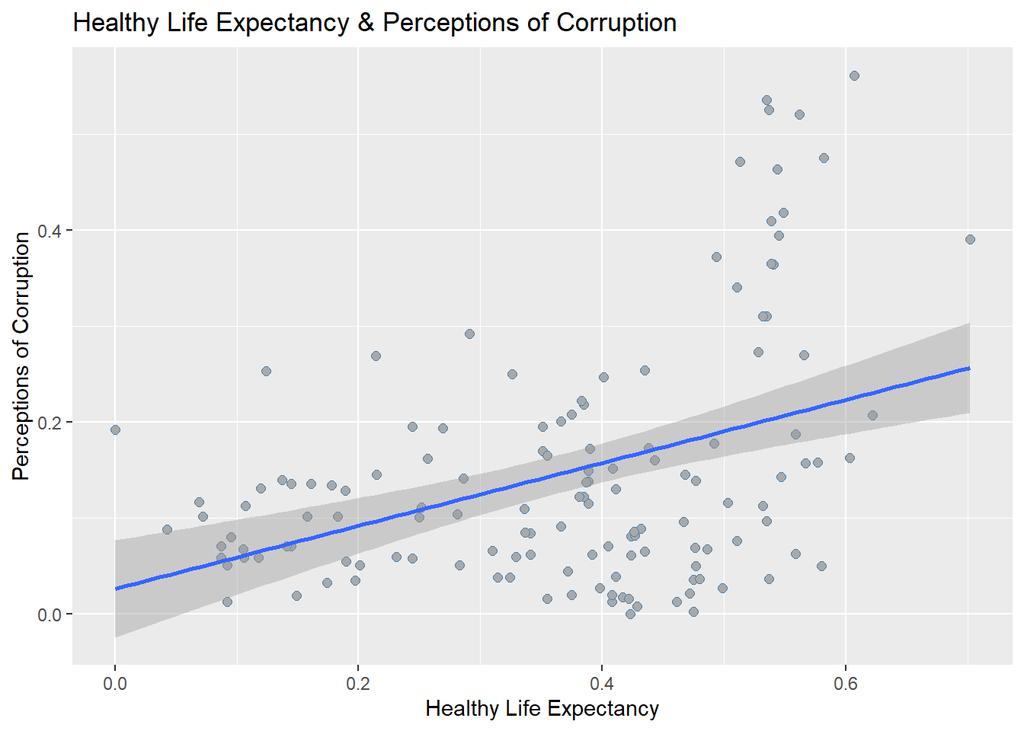

```r
ggplot(data=df, mapping=aes(x=healthy_life_expectancy,y=perceptions_of_corruption)) +
  geom_point(pch=21,color="steelblue",fill="darkgray",size=2) +
  labs(x="Healthy Life Expectancy",y="Perceptions of Corruption", title = "Healthy Life Expectancy & Perceptions of Corruption") +   geom_smooth(method="lm")
```

healthy_life_expectancy and perceptions_of_corruption have a linear relationship. The higher healthy_life_expectancy, the higher perceptions_of_corruption.

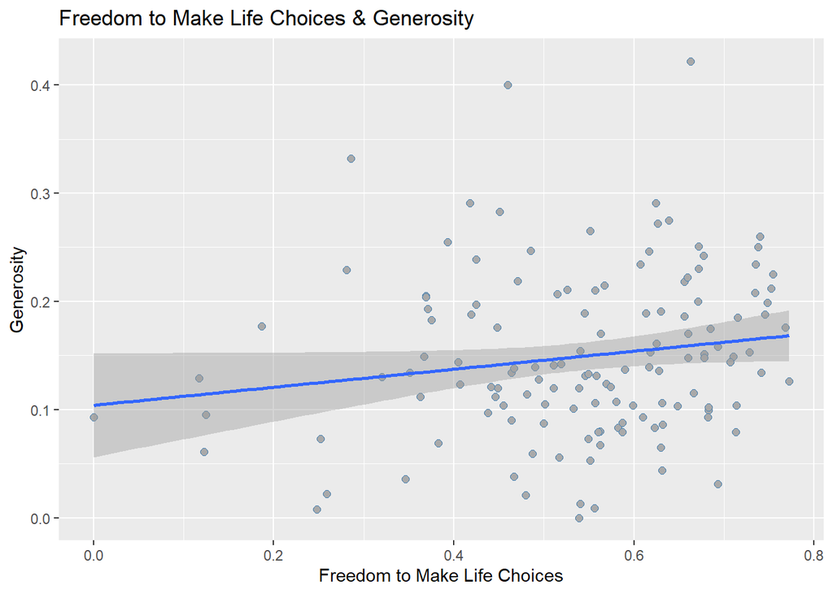

```r
ggplot(data=df, mapping=aes(x=freedom_to_make_life_choices,y=generosity)) +
  geom_point(pch=21,color="steelblue",fill="darkgray",size=2) +
  labs(x="Freedom to Make Life Choices",y="Generosity", title = "Freedom to Make Life Choices & Generosity") +   geom_smooth(method="lm")
```

freedom_to_make_life_choices and generosity have a linear relationship. The higher the freedom_to_make_life_choices, the higher the generosity.

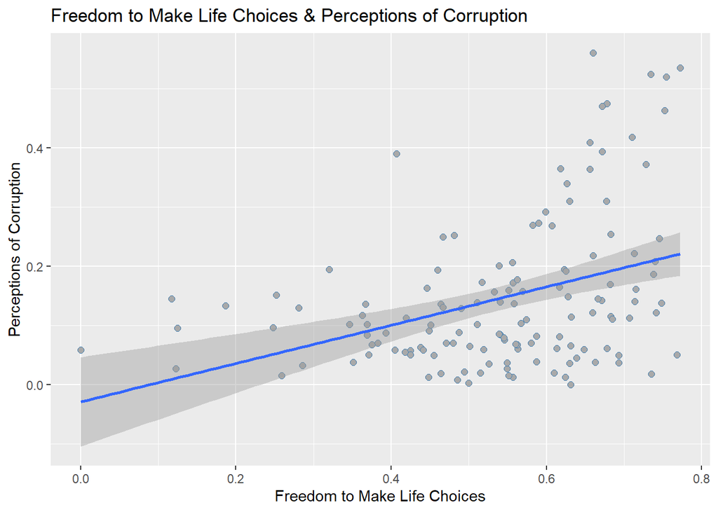

```r
ggplot(data=df, mapping=aes(x=freedom_to_make_life_choices,y=perceptions_of_corruption)) +
  geom_point(pch=21,color="steelblue",fill="darkgray",size=2) +
  labs(x="Freedom to Make Life Choices",y="Perceptions of Corruption", title = "Freedom to Make Life Choices & Perceptions of Corruption") +   geom_smooth(method="lm")
```

freedom_to_make_life_choices and perceptions_of_corruption have a linear relationship. The higher freedom_to_make_life_choices, the higher perceptions_of_corruption.

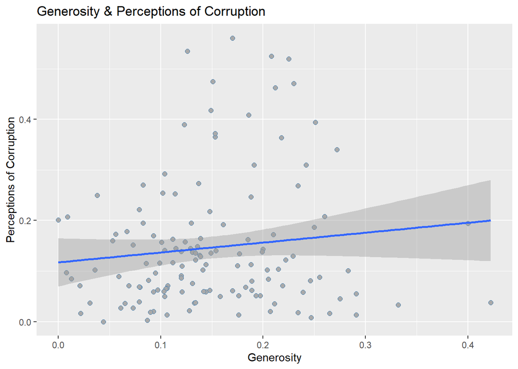

```r
ggplot(data=df, mapping=aes(x=generosity,y=perceptions_of_corruption)) +
  geom_point(pch=21,color="steelblue",fill="darkgray",size=2) +
  labs(x="Generosity",y="Perceptions of Corruption", title = "Generosity & Perceptions of Corruption") +   geom_smooth(method="lm")
```

loyalty and perceptions_of_corruption have a linear relationship. The higher the generosity, the higher the perception_of_corruption.

## Comparing Indonesian Data with Other Countries

```r
#filter indonesia data
indonesias <- df %>%
  filter(country == "Indonesia")

others <- df %>%
  filter(country != "Indonesia")

rows <- c("happiness_score", "gdp_per_capita", "social_support", "healthy_life_expectancy", "freedom_to_make_life_choices", "generosity", "perceptions_of_corruption")

comparison <- data.frame(Index = rows,
  Indonesia = c(indonesias$happiness_score, indonesias$gdp_per_capita, indonesias$social_support, indonesias$healthy_life_expectancy, indonesias$freedom_to_make_life_choices, indonesias$generosity, indonesias$perceptions_of_corruption),
  Other = c(mean(others$happiness_score), mean(others$gdp_per_capita), mean(others$social_support), mean(others$healthy_life_expectancy), mean(others$freedom_to_make_life_choices), mean(others$generosity), mean(others$perceptions_of_corruption))
)
comparison
```

```
##                          Index Indonesia     Other
## 1              happiness_score     5.277 5.5464222
## 2               gdp_per_capita     1.384 1.4091037
## 3               social_support     1.169 1.1549852
## 4      healthy_life_expectancy     0.314 0.3665630
## 5 freedom_to_make_life_choices     0.663 0.5400074
## 6                   generosity     0.422 0.1470667
## 7    perceptions_of_corruption     0.038 0.1472815
```

Dataframe comparison compares the values of each variable for Indonesia with other countries. With this dataframe, we can compare the condition of Indonesia’s happiness rate with other countries and the variables that influence it. Based on the dataframe comparison above, Indonesia’s happiness_score is slightly below the average happiness_score of other countries, as well as variables such as gdp_per_capita, healthy_life_expectancy, and perceptions_of_corruption. Meanwhile, variables such as social_support, freedom_to_make_life_choices, and generosity are slightly above the average for other countries. Thus, Indonesia’s overall happiness_score is 5,277. The comparison dataframe is then visualized in the bar plot below.

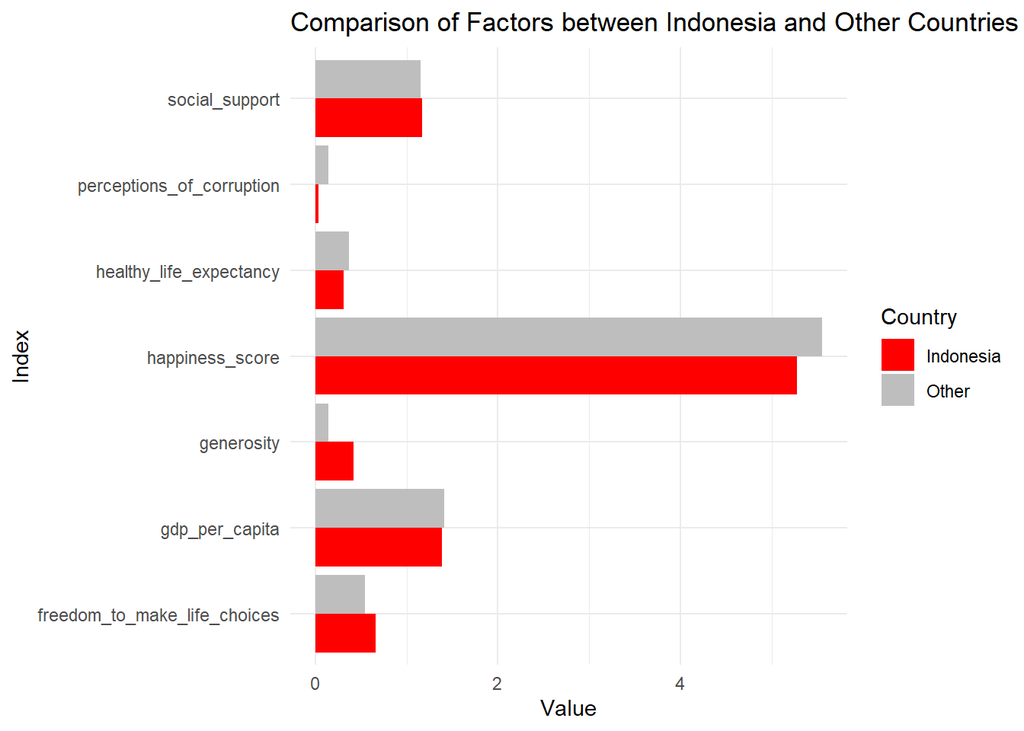

```r
comparison_long <- tidyr::pivot_longer(comparison, cols = c(Indonesia, Other),
                                       names_to = "Country", values_to = "Value")

ggplot(comparison_long, aes(x = Value, y = Index, fill = Country)) +
  geom_bar(stat = "identity", position = position_dodge()) +
  labs(title = "Comparison of Factors between Indonesia and Other Countries",
       x = "Value", y = "Index") +
  scale_fill_manual(values = c("Indonesia" = "red", "Other" = "grey")) +
  theme_minimal()
```

## Conclusion

From the World Happiness Records 2023 dataset, it can be concluded that the country with the highest happiness record is Finland, with a happiness score of 7,804. Meanwhile, there are 12 countries with a happiness record of more than 7.0, namely, Finland, Denmark, Iceland, Israel, Netherlands, Sweden, Norway, Switzerland, Luxembourg, New Zealand, Austria, Australia.

Therefore, in conclusion, a country’s happiness score is influenced by the following factors: how big a country’s GDP per capita is, the quality of social support offered by a country and the quality of a person’s social life, how high a country’s healthy life expectancy is, and also how much opportunity a person has to make a decision.

Indonesia has a happiness_score of 5,277 which is slightly below the average happiness_score of other countries. This is not too bad, but there are still many factors that can be improved so that Indonesia’s happiness_score can increase, such as in terms of the level of corruption, healthy life expectancy, and GDP per capita.